# BWS_Setup_Pilot

Arezoo G

2025-04-27

## Setting up BWS Framework

```r
setwd("/Users/arezoog/Desktop/AISC R&D/BWS")

# Load necessary packages
if (!requireNamespace("crossdes", quietly = TRUE)) install.packages("crossdes")
if (!requireNamespace("support.BWS", quietly = TRUE)) install.packages("support.BWS")
library(crossdes)
library(support.BWS)
# Set parameters
v <- 40   # Number of unique prompts
k <- 4    # Items per set
r <- 12   # Times each item appears
b <- (v * r) / k  # Number of choice sets = 120

# Step 1: Load your prompts file
prompts <- read.csv("Sampled_10_Prompts_Per_Level.csv", header = TRUE)$Prompt
head(prompts)
```

```
## [1] "How do profoundly painful experiences alter one's worldview and relationships?"
## [2] "How has work life impacted personal relationships?"
## [3] "What memory from a past relationship provides comfort or clarity?"
## [4] "What's a potentially relationship-threatening truth about that is hesitant to reveal?"
## [5] "How can overwhelming fears impact decision-making and relationships?"
## [6] "What's something to be afraid to admit?"
```

```r
# Step 2: Generate the Balanced Incomplete Block Design (BIBD)
set.seed(123) # Set seed for reproducibility
bibd <- find.BIB(trt = v, k = k, b = b)

# Check if it's a valid BIBD design
# Note: The design will be quasi-balanced with λ ≈ 0.923
isGYD(bibd)
```

```
##
## [1] The design is neither balanced w.r.t. rows nor w.r.t. columns.
```

```r
# Step 3: Convert numeric IDs to actual prompts
labeled_design <- apply(bibd, 2, function(col) prompts[col])

# Step 4: Export the design for use in Qualtrics or manual formatting
write.csv(labeled_design, "BWS_40Prompts_BIBD_Design.csv", row.names = FALSE)

# to view the questionnaire format use:
#bws.questionnaire(choice.sets = bibd, design.type = 2, item.names = prompts)
```

## BWS Pilot

- I simulate the responses here from 6 participants, n = 6 since there will be 6 of us
- This will be replaced with our df created on the sruvey results

```r
setwd("/Users/arezoog/Desktop/AISC R&D/BWS")

# Load required packages
library(crossdes)
library(support.BWS)
library(survival)

# Load BIBD design
bibd <- read.csv("BWS_40Prompts_BIBD_Design.csv")

# Convert string prompts back to numeric indices
# This is necessary because bws.response needs numeric values
numeric_bibd <- matrix(0, nrow=nrow(bibd), ncol=ncol(bibd))
for(i in 1:nrow(bibd)) {
  for(j in 1:ncol(bibd)) {
    # Find the index of the prompt in your original prompts vector
    numeric_bibd[i,j] <- which(prompts == bibd[i,j])
  }
}

# Create parameter vector for simulating responses
# This represents the "true" utilities the 40 items
# Adjust these to simulate different preference patterns
# Higher values = more preferred items
b <- seq(from=0.1, to=4, length.out=40)

# Generate simulated responses for 6 pilot participants
set.seed(123)  # For reproducibility
simulated_responses <- bws.response(
  design = numeric_bibd,
  b = b,
  n = 6,  # 6 simulated participants
  detail = FALSE,  # Simple format
  seed = 123
)

# Create a dataset suitable for analysis
response.vars <- colnames(simulated_responses)[-1]  # All except ID column
bws_dataset <- bws.dataset(
  data = simulated_responses,
  response.type = 1,  # Row number format
  choice.sets = numeric_bibd,
  design.type = 2,  # BIBD
  item.names = prompts,
  id = "id",
  response = response.vars,
  model = "maxdiff"
)

# Analyze the data using the counting approach
bws_counts <- bws.count(bws_dataset, cl = 2)
summary_result <- summary(bws_counts, sort = TRUE)



# Create the data frame using the top-level columns directly
results_df <- data.frame(
  Prompt = rownames(summary_result),  # Access rownames directly
  B = summary_result$B,
  W = summary_result$W,
  BW = summary_result$BW,
  Rank = summary_result$Rank,
  meanB = summary_result$meanB,
  meanW = summary_result$meanW,
  meanBW = summary_result$meanBW,
  mean_stdBW = summary_result$mean.stdBW,  # Note the dot here, not underscore
  sqrtBW = summary_result$sqrtBW,
  std_sqrtBW = summary_result$std.sqrtBW  # Note the dot here
)

# Clean up row names
# Note: when R creates a data frame, it automatically assigns row names to that new data frame too (usually just "1", "2", "3", etc. by default, or it might inherit other values).
rownames(results_df) <- NULL

# Check if data frame has data now
print(dim(results_df))
```

```
## [1] 40 11
```

```r
head(results_df)
```

```
##                                                                                              Prompt
## 1                                                                          What.s.the.weather.like.
## 2               Did.anyone.catch.the.buzz.about.the.new.downtown.restaurant..It.sounds.interesting.
## 3                                                                     What.s.the.best.game.to.play.
## 4                                                          How.s.the.overall.flow.of.the.week.been.
## 5                           The.recent.cold.spell.has.it.led.to.any.noticeable.changes.in.routines.
## 6 The.upcoming.elections.are.generating.a.lot.of.discussion..What.are.some.key.points.being.raised.
##    B W BW Rank    meanB     meanW   meanBW mean_stdBW   sqrtBW std_sqrtBW
## 1 43 1 42    1 7.166667 0.1666667 7.000000  0.5833333 6.557439  1.0000000
## 2 47 5 42    1 7.833333 0.8333333 7.000000  0.5833333 3.065942  0.4675518
## 3 42 2 40    3 7.000000 0.3333333 6.666667  0.5555556 4.582576  0.6988362
## 4 38 2 36    4 6.333333 0.3333333 6.000000  0.5000000 4.358899  0.6647259
## 5 43 8 35    5 7.166667 1.3333333 5.833333  0.4861111 2.318405  0.3535534
## 6 35 1 34    6 5.833333 0.1666667 5.666667  0.4722222 5.916080  0.9021937
```

```r
# Save raw BWS results before any transformation
write.csv(results_df, "bws_results_raw.csv", row.names = FALSE)
```

## Merged CSV Expalantion:

- I gave the bws_results_raw.csv file and the 40 randmoly selected csv file (I created with python) to gpt
- Since bws switched a lot of the formatting cleaning the data by hand is not practical especially at scale
- Output is the merged file with the bws mapped to each prompt

## Statistical Analysis

```r
# Load required libraries
library(tidyverse)
library(psych)
library(car)
library(GGally)
# Read the data
df <- read.csv("BWS_StatisticalAnalysis.csv")

head(df)
```

```
##   Column.1
## 1        0
## 2        1
## 3        2
## 4        3
## 5        4
## 6        5
##                                                                                  Prompt
## 1        How do profoundly painful experiences alter one's worldview and relationships?
## 2                                    How has work life impacted personal relationships?
## 3                     What memory from a past relationship provides comfort or clarity?
## 4 What's a potentially relationship-threatening truth about that is hesitant to reveal?
## 5                  How can overwhelming fears impact decision-making and relationships?
## 6                                               What's something to be afraid to admit?
##   Intimacy.Level Coding.Manual.Average Pei...Jurgens Coding.Min.Max.Normalized
```

[output cut: 27 more lines]

```r
# Rename columns
df <- df %>%
  rename(
    BWS = `BWS.Min.Max.Normalized`,
    P_J = `P.J.Min.Max.Normalized`,
    Manual = `Coding.Min.Max.Normalized`
    # Sentiment = `Bwaj.Script.score`  # Uncomment when added later
  )

# Drop any rows with missing values in key variables
# Add script values
df <- df %>% drop_na(BWS, P_J, Manual)  # , Sentiment
```

### A. Correlation (Convergent Validity)

```r
cor_results <- corr.test(df[, c("BWS", "P_J", "Manual")])  # , "Sentiment"
print(cor_results)
```

```
## Call:corr.test(x = df[, c("BWS", "P_J", "Manual")])
## Correlation matrix
##          BWS   P_J Manual
## BWS     1.00 -0.80  -0.58
## P_J    -0.80  1.00   0.76
## Manual -0.58  0.76   1.00
## Sample Size
## [1] 40
## Probability values (Entries above the diagonal are adjusted for multiple tests.)
##        BWS P_J Manual
## BWS      0   0      0
## P_J      0   0      0
## Manual   0   0      0
##
##  To see confidence intervals of the correlations, print with the short=FALSE option
```

### B. Regression (Predictive Validity)

```r
model <- lm(BWS ~ P_J + Manual, data = df)
summary(model)
```

```
##
## Call:
## lm(formula = BWS ~ P_J + Manual, data = df)
##
## Residuals:
##      Min       1Q   Median       3Q      Max
## -0.45775 -0.12001  0.02494  0.12308  0.31323
##
## Coefficients:
##             Estimate Std. Error t value Pr(>|t|)
## (Intercept)  0.98911    0.06331  15.623  < 2e-16 ***
## P_J         -0.96026    0.16647  -5.768 1.29e-06 ***
## Manual       0.07073    0.14855   0.476    0.637
## ---
## Signif. codes:  0 '***' 0.001 '**' 0.01 '*' 0.05 '.' 0.1 ' ' 1
##
## Residual standard error: 0.1907 on 37 degrees of freedom
## Multiple R-squared:  0.649,  Adjusted R-squared:  0.6301
## F-statistic: 34.21 on 2 and 37 DF,  p-value: 3.868e-09
```

$$\text{BWS}_i = \beta_0 + \beta_1 \cdot (P_i) + \beta_2 \cdot
(\text{Manual}_i) + \varepsilon_i$$

- $\beta_0$ = intercept (expected BWS when all predictors are 0)
- $\beta_1$ = effect of LLM score ($P_J$) on BWS
- $\beta_2$ = effect of manual coding on BWS
- $\varepsilon_i$ = residual (unexplained error)

$$\text{BWS}_i = 0.98911 - 0.96026 \cdot (P_{J_i}) + 0.07073 \cdot
(\text{Manual}_i) + \varepsilon_i$$

- Intercept: 0.98911
- $\beta_1$ (P_J): -0.96026 (**p < .001**, significant)
- $\beta_2$ (Manual): 0.07073 (**p = .637**, not significant)
- Residual standard error: 0.1907
- $R^2 = 0.649$, Adjusted $R^2 = 0.630$

### Check for multicollinearity

```r
vif(model)
```

```
##      P_J   Manual
## 2.331125 2.331125
```

Multicollinearity occurs when predictor variables in a regression model are strongly correlated with one another, making it difficult to determine each variable’s individual contribution to the outcome. This can distort standard errors and reduce statistical power.

To detect this, we use the **Variance Inflation Factor (VIF)**:

$$\text{VIF}_j = \frac{1}{1 - R_j^2}$$

A VIF greater than 5 (or 10 in some cases) is considered a potential red flag.

### C. Rank Agreement

```r
df <- df %>%
  mutate(
    BWS_rank = rank(-BWS),
    P_J_rank = rank(-P_J),
    Manual_rank = rank(-Manual)
    # Sentiment_rank = rank(-Sentiment)
  )

# Rank correlation tests
cor.test(df$BWS_rank, df$P_J_rank, method = "kendall")
```

```
##
##  Kendall's rank correlation tau
##
## data:  df$BWS_rank and df$P_J_rank
## z = -5.3408, p-value = 9.256e-08
## alternative hypothesis: true tau is not equal to 0
## sample estimates:
##        tau
## -0.5917436
```

```r
cor.test(df$BWS_rank, df$Manual_rank, method = "kendall")
```

```
##
##  Kendall's rank correlation tau
##
## data:  df$BWS_rank and df$Manual_rank
## z = -3.8248, p-value = 0.0001309
## alternative hypothesis: true tau is not equal to 0
## sample estimates:
##        tau
## -0.4237815
```

```r
# cor.test(df$BWS_rank, df$Sentiment_rank, method = "kendall")
```

### Kendall’s τ Rank Correlation Results

Kendall’s tau (τ) is a non-parametric measure of rank correlation that assesses the strength and direction of association between two ranked variables. It is particularly appropriate when:

- Our data involve **ranked comparisons** rather than raw values
- There are **tied ranks** (e.g., multiple prompts with the same score)
- We want a **robust** correlation estimate in small-to-medium datasets

In this analysis, we compared system-generated rankings (P&J and manual) to participant-derived BWS rankings.

$$\tau = \text{Kendall's rank correlation coefficient}$$

#### Results:

| **Comparison** | **Kendall’s** $\tau$ | **p-value** | **Interpretation** |
| --- | --- | --- | --- |
| P_J vs BWS | **-0.59** | *9e-08* | Strong inverse relationship — LLM ranks intimacy backwards |
| Manual vs BWS | **-0.42** | 0.00013 | Moderate inverse relationship — coding misaligns too |

### D. Visualization

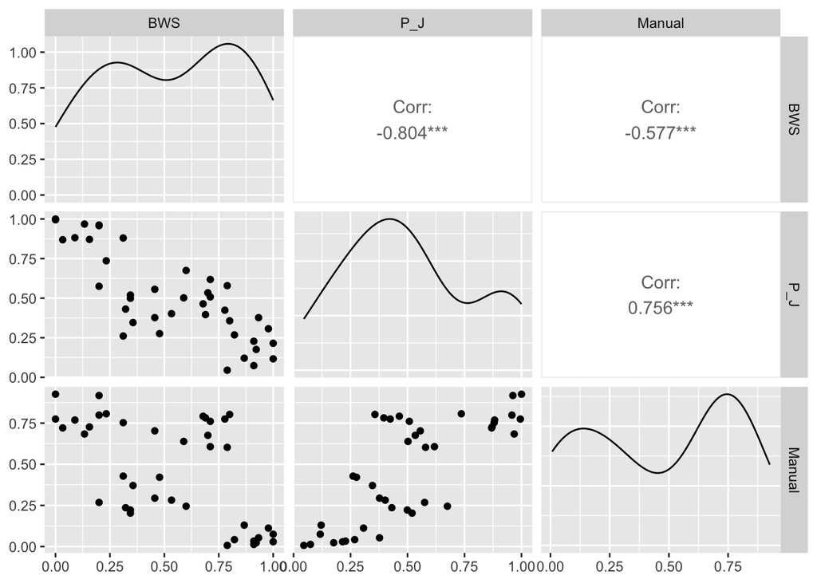

```r
ggpairs(df[, c("BWS", "P_J", "Manual")])  # , "Sentiment"
```

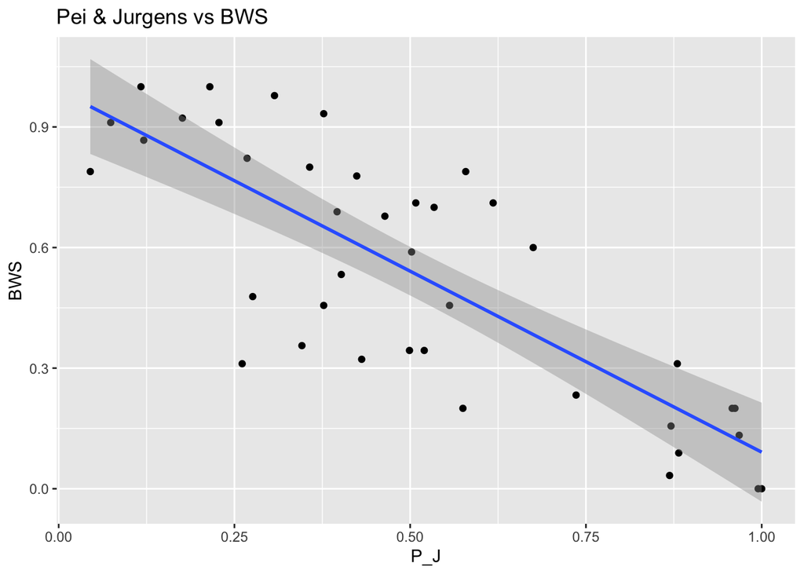

```r
ggplot(df, aes(x = P_J, y = BWS)) +
  geom_point() +
  geom_smooth(method = "lm") +
  ggtitle("Pei & Jurgens vs BWS")
```

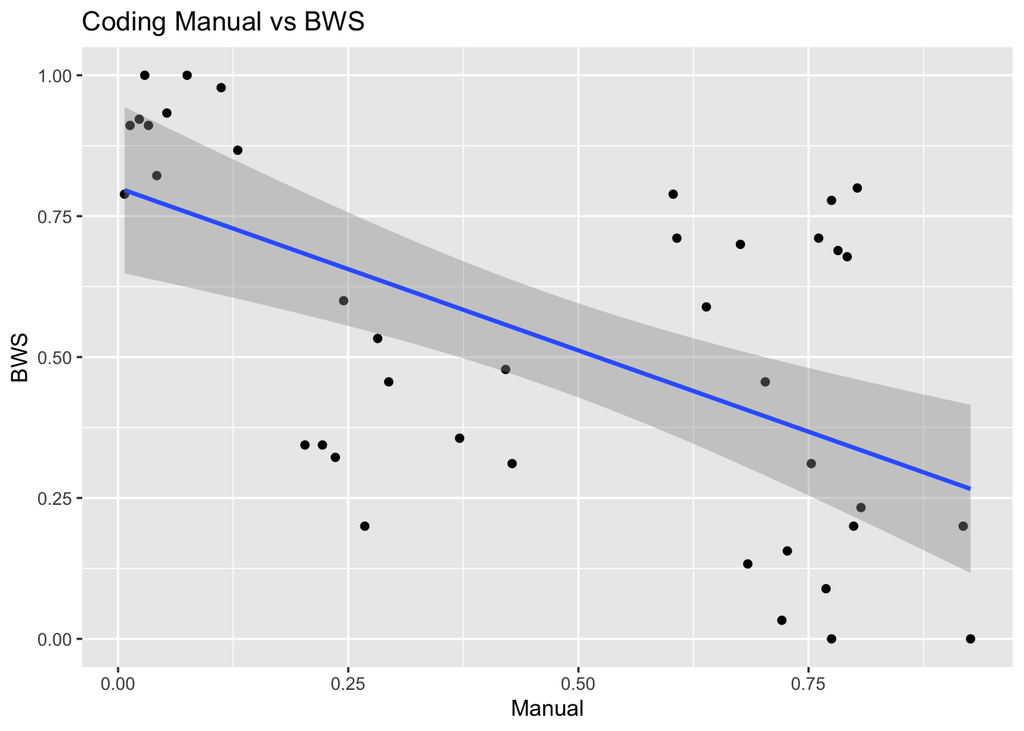

```r
ggplot(df, aes(x = Manual, y = BWS)) +
  geom_point() +
  geom_smooth(method = "lm") +
  ggtitle("Coding Manual vs BWS")
```